# Stationarity Analysis and Forecasting via ARIMA

Liva Dogan

1/29/2021

### 1. Introduction

This report is prepared to observe the daily electricity consumption of Turkey and to forecast the future consumption levels. Since daily consumption data series is non-stationary due to different reasons as stated in the class, the first step of forecasting should be making the data stationary. After reaching a stationary series, an ARIMA model to forecast future values can be used for this case. Finally, we can comment on the reliability of this forecasting model by checking some error statistics.

### 2. Stationarity Analysis

Before starting forecasting, we should observe the series visually in order to be able to comment on its properties. However, we need some arrangements on data since it is provided as hourly but we need daily forecast. In order to manipulate the data to the form we need, following lines are applied:

```r
consumption <- read_excel("Real Time Consumption Excel.xls")
consumption = data.table(consumption)
consumption$Date <- as.Date(consumption$Date, "%d.%m.%Y")

Mean_Consumption <- c(0, 0, 0)
consumption = cbind(consumption, Mean_Consumption)
for (i in seq(1, 35256, by = 24))
{
  daily_cons = 0
  for (k in 0:23)
  {
    daily_cons = daily_cons + consumption$Consumption[(i+k)]
  }
  consumption$Mean_Consumption[i] = daily_cons / 24
}

consumption <- consumption[consumption$Hour == "00:00"]
consumption <- consumption[, !"Hour"]
consumption <- consumption[, !"Consumption"]
```

After these steps, the series is ready to plot.

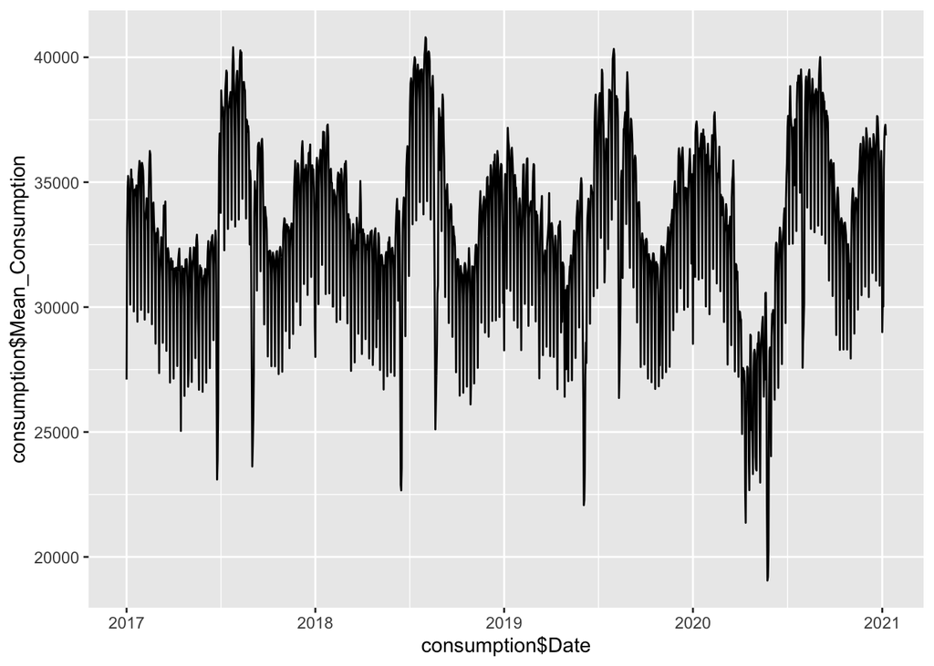

As it is seen above, the mean goes up and down over time and variance is not constant at all, which are the two signs of non-stationarity. There are some rapid decreases among time, which are the religious holidays, except the last rapid decrease. The last one is effect of pandemic on the industrial consumption. Furthermore, the seasonality of data can be seen clearly by checking the line graph. For further observation, we can use the autocorrelation graph:

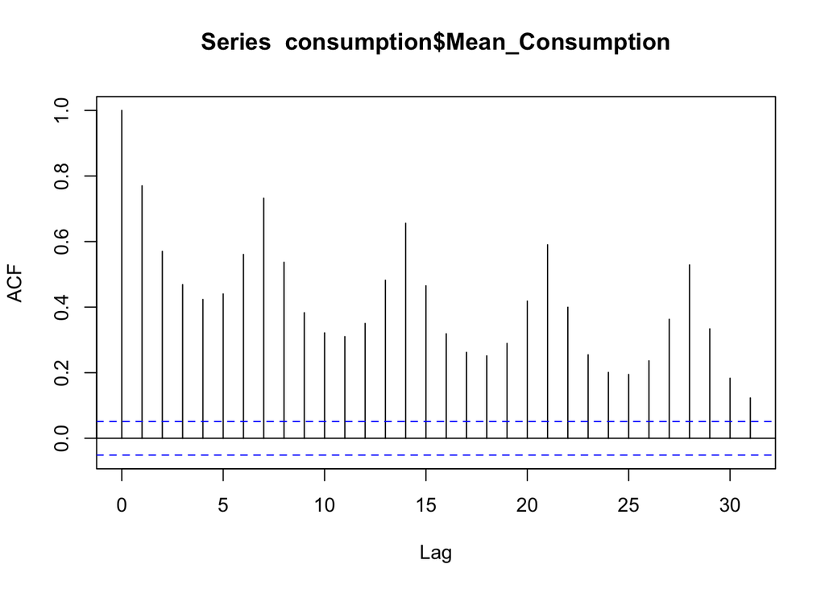

The autocorrelation observed on data is too high to be stationary. Also, the pattern of the bars reflects the seasonality. As it is seen, the autocorrelation value is higher than its neighbors for lag 7, lag 14 etc. These values show that the seasonality of consumption data is weekly. This information will be used while building the model.

One way to avoid stationarity is to take differences between different dates. Since this consumption data has weekly seasonality, we can use the differences between the day and seven day before that day to have a stationary data.

```r
consumption[, WeeklyDiff := Mean_Consumption-shift(Mean_Consumption, 7)]
```

After adding the weekly difference to the data, we can check whether it becomes stationary or not by simply looking at the line graph and autocorrelation plot.

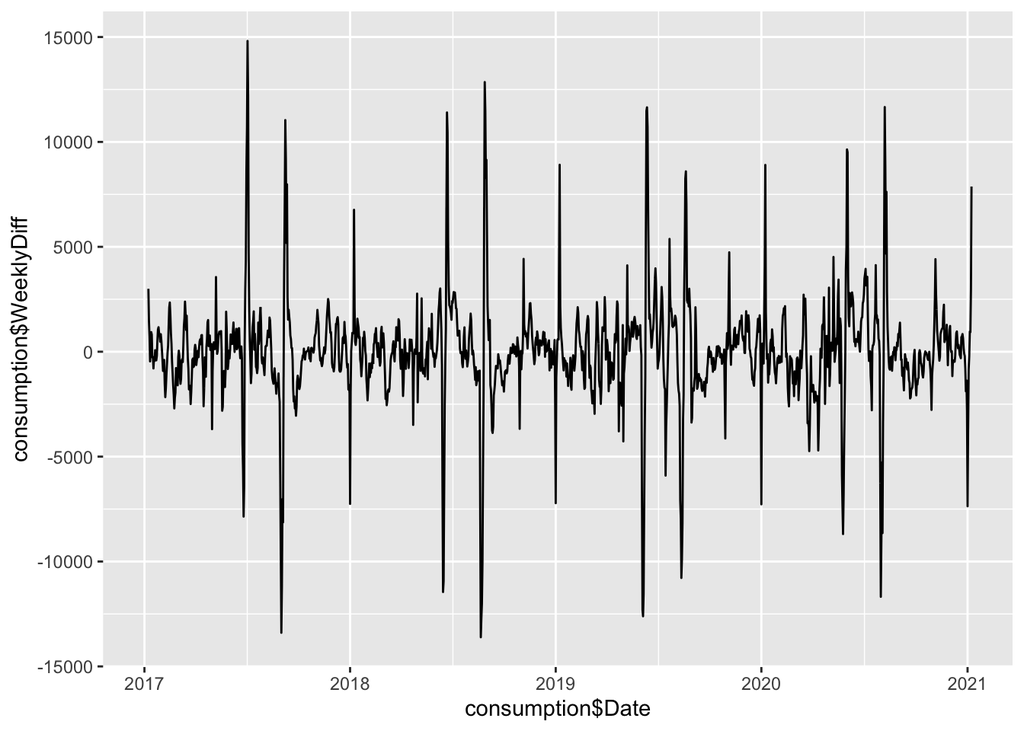

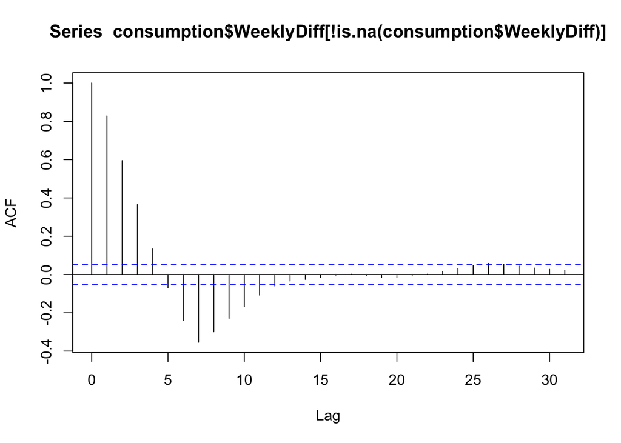

For the line graph, we can easily say that the mean does not change significantly as the previous one and it is around zero. On the other hand, variance seems to change over time, which is an unwanted situation. However, we can comment on the variance as it remains constant over time but there are some outlier points, as religious holidays or special days, and ignoring them does not significantly affect our assumption constant variance.

For further information, we can apply different tests for stationarity. Two of them are Ljung-Box test and KPSS Unit Root test.

```
##
##  Box-Ljung test
##
## data:  consumption$WeeklyDiff
## X-squared = 2023.4, df = 7, p-value < 2.2e-16
```

```
##
## #######################
## # KPSS Unit Root Test #
## #######################
##
## Test is of type: mu with 7 lags.
##
## Value of test-statistic is: 0.0121
##
## Critical value for a significance level of:
##                 10pct  5pct 2.5pct  1pct
## critical values 0.347 0.463  0.574 0.739
```

### 3. ARIMA Model Building and Forecasting

Since we have a stationary series, we can apply an ARIMA model to forecast the future consumption. But, deciding which parameters to use on model is not determined. To determine the parameters, we can easily call a function called “auto.arima()”, which evaluates AIC and BIC values for different parameter sets and returns the parameter set that provides the smallest AIC/BIC.

```
##
##  Fitting models using approximations to speed things up...
##
##  ARIMA(2,0,2) with non-zero mean : 25141.3
##  ARIMA(0,0,0) with non-zero mean : 27068.03
##  ARIMA(1,0,0) with non-zero mean : 25349.74
##  ARIMA(0,0,1) with non-zero mean : 25948.16
##  ARIMA(0,0,0) with zero mean     : 27066.04
##  ARIMA(1,0,2) with non-zero mean : 25226.47
##  ARIMA(2,0,1) with non-zero mean : 25142.99
##  ARIMA(3,0,2) with non-zero mean : 25145.39
##  ARIMA(2,0,3) with non-zero mean : 25091.19
##  ARIMA(1,0,3) with non-zero mean : 25207.87
##  ARIMA(3,0,3) with non-zero mean : Inf
##  ARIMA(2,0,4) with non-zero mean : Inf
##  ARIMA(1,0,4) with non-zero mean : 25171.37
##  ARIMA(3,0,4) with non-zero mean : Inf
##  ARIMA(2,0,3) with zero mean     : 25089.27
##  ARIMA(1,0,3) with zero mean     : 25205.87
##  ARIMA(2,0,2) with zero mean     : 25139.32
##  ARIMA(3,0,3) with zero mean     : Inf
##  ARIMA(2,0,4) with zero mean     : Inf
##  ARIMA(1,0,2) with zero mean     : 25224.46
##  ARIMA(1,0,4) with zero mean     : 25169.35
##  ARIMA(3,0,2) with zero mean     : 25143.4
##  ARIMA(3,0,4) with zero mean     : Inf
##
##  Now re-fitting the best model(s) without approximations...
##
##  ARIMA(2,0,3) with zero mean     : Inf
##  ARIMA(2,0,3) with non-zero mean : Inf
##  ARIMA(2,0,2) with zero mean     : 25140.13
##
##  Best model: ARIMA(2,0,2) with zero mean
```

This function states that the best model can be applied for this data is ARIMA(2,0,2) with zero-mean. The function gives the difference parameter as 0 because the the difference is applied before. After that, the forecasted values are ready by these 2 lines:

```r
nahead = 15
forecast_values <- forecast(arima_model, h = nahead)
```

```
##           Date Mean_Consumption WeeklyDiff  Pred_Diff Forecast
##  1: 2020-12-30         36249.17 -1369.4671 -1369.4671 36249.17
##  2: 2020-12-31         34342.43 -2800.9775 -2800.9775 34342.43
##  3: 2021-01-01         28998.90 -7368.2138 -7368.2138 28998.90
##  4: 2021-01-02         30276.93 -3670.2208 -3670.2208 30276.93
##  5: 2021-01-03         30023.36  -834.8233  -834.8233 30023.36
##  6: 2021-01-04         35548.28  -217.6025  -217.6025 35548.28
##  7: 2021-01-05         36723.26   960.0542   960.0542 36723.26
##  8: 2021-01-06         37182.32   933.1500   933.1500 37182.32
##  9: 2021-01-07         37299.57  2957.1433  2957.1433 37299.57
## 10: 2021-01-08         36873.90  7874.9946  7874.9946 36873.90
## 11: 2021-01-09         34781.56         NA  7630.4453 37907.38
## 12: 2021-01-10         31841.90         NA  6266.3092 36289.67
## 13: 2021-01-11         36431.46         NA  4556.4776 40104.76
## 14: 2021-01-12         36897.99         NA  2765.3907 39488.65
## 15: 2021-01-13         37409.87         NA  1103.5021 38285.83
## 16: 2021-01-14         38056.05         NA  -282.3942 37017.18
## 17: 2021-01-15         38170.38         NA -1309.7504 35564.15
## 18: 2021-01-16         35667.35         NA -1953.8529 32827.71
## 19: 2021-01-17         32557.96         NA -2236.7571 29605.14
## 20: 2021-01-18         38447.89         NA -2213.8501 34217.61
## 21: 2021-01-19         39723.73         NA -1960.0408 34937.95
## 22: 2021-01-20         39960.92         NA -1557.1368 35852.73
## 23: 2021-01-21         39791.07         NA -1083.4770 36972.58
## 24: 2021-01-22         38902.97         NA  -606.3910 37563.99
## 25: 2021-01-23         35635.70         NA  -177.6200 35489.73
##           Date Mean_Consumption WeeklyDiff  Pred_Diff Forecast
```

### 4. Statistical Analysis and Comparison

Firstly, we can observe the line graphs of actual and forecasted consumption values to see the similiarity between them:

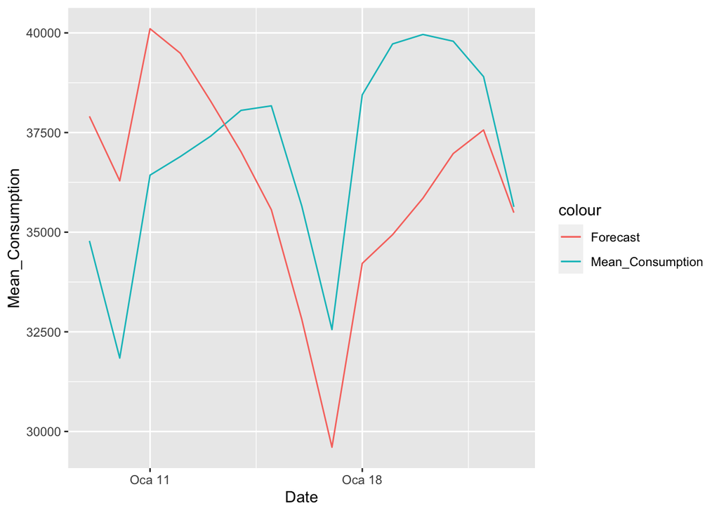

```
##    n     mean       sd       bias       mape      mad      wmape
## 1 15 36951.79 2500.597 0.02192364 0.07550318 2771.916 0.07501439
```

As it is seen, MAPE and WMAPE values are really small, which shows that the reliability of the model is supported by these small error calculations.

### 5. Conclusion

```
##           Date Mean_Consumption WeeklyDiff  Pred_Diff Forecast
##  1: 2021-01-09         34781.56         NA  7630.4453 37907.38
##  2: 2021-01-10         31841.90         NA  6266.3092 36289.67
##  3: 2021-01-11         36431.46         NA  4556.4776 40104.76
##  4: 2021-01-12         36897.99         NA  2765.3907 39488.65
##  5: 2021-01-13         37409.87         NA  1103.5021 38285.83
##  6: 2021-01-14         38056.05         NA  -282.3942 37017.18
##  7: 2021-01-15         38170.38         NA -1309.7504 35564.15
##  8: 2021-01-16         35667.35         NA -1953.8529 32827.71
##  9: 2021-01-17         32557.96         NA -2236.7571 29605.14
## 10: 2021-01-18         38447.89         NA -2213.8501 34217.61
## 11: 2021-01-19         39723.73         NA -1960.0408 34937.95
## 12: 2021-01-20         39960.92         NA -1557.1368 35852.73
## 13: 2021-01-21         39791.07         NA -1083.4770 36972.58
## 14: 2021-01-22         38902.97         NA  -606.3910 37563.99
## 15: 2021-01-23         35635.70         NA  -177.6200 35489.73
```

To reach the RMD file, please click [here](https://bu-ie-360.github.io/fall20-livadogann/files/homework4.Rmd).